# SeamlessM4T Model Architecture

從 Seamless 整合架構到 UnitY2 與表現力控制

柏緯 · Speech Lab

2026-10-15

## 這份報告要回答什麼？

模型如何把「說什麼」翻成另一種語言，  
再把「怎麼說」帶進生成語音？

- **家族定位**：M4T v2、Expressive、Streaming 各自解決什麼問題？
- **架構拆解**：從語音特徵、目標文字，一路走到語音單元與波形。
- **關鍵機制**：T2U 如何靠 duration 預測，把文字長度展開成語音長度？

內容主線：使用者提供的 RTF、Expressive 與 UnitY2 截圖，以及 Seamless 整合架構圖。

## Seamless AI 家族：三個技術支柱

| 模型 | 核心問題 | 關鍵設計 |
| --- | --- | --- |
| **SeamlessM4T v2** | 多模態、多任務翻譯 | UnitY2／Multitask-UnitY2 基礎骨幹 |
| **SeamlessExpressive** | 跨語言保留韻律與聲音風格 | 表現力條件＋expressive speech generation |
| **SeamlessStreaming** | 不等整句結束就開始翻譯 | EMMA 串流輸出決策 |
| **Seamless** | 結合表現力與串流翻譯 | 整合上述能力 |

先看 Seamless 的整合全貌，再拆解 Expressive 與 M4T v2／UnitY2。

來源：使用者 RTF §1；[Meta 官方模型庫](https://github.com/facebookresearch/seamless_communication)。

## M4T v2：同一骨幹支援五種任務

| 任務 | 輸入 → 輸出 | 是否需要 T2U 與語音合成？ |
| --- | --- | --- |
| ASR | 語音 → 同語言文字 | 否 |
| S2TT | 語音 → 目標語言文字 | 否 |
| T2TT | 文字 → 目標語言文字 | 否 |
| S2ST | 語音 → 目標語言語音 | **是** |
| T2ST | 文字 → 目標語言語音 | **是** |

輸入模態決定 encoder；輸出模態決定是否繼續產生 unit 與波形。

來源：使用者 RTF §1；[Transformers：SeamlessM4T-v2](https://huggingface.co/docs/transformers/model_doc/seamless_m4t_v2#model-architecture)。

## Seamless：串流翻譯與表現力合成

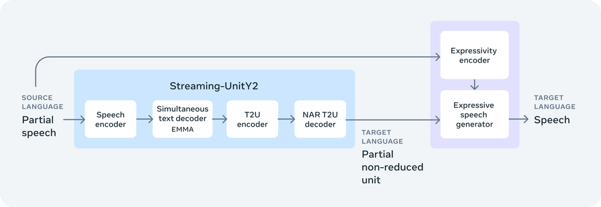

**Streaming-UnitY2** 決定翻譯內容與輸出時機；**expressive generator** 加入來源聲音風格。

圖片：[Meta 官方技術介紹 · Seamless](https://ai.meta.com/resources/models-and-libraries/seamless-communication-models/)，與本次附圖內容相同；直接使用官方原圖。

## 串流推論：輸入、讀寫決策與輸出

| 階段 | 架構說明 |
| --- | --- |
| **輸入：Partial speech** | 逐步接收音訊，保留已取得的上下文，不需等整句結束。 |
| **核心：Streaming-UnitY2＋EMMA** | 同步文字解碼器依上下文決定 **READ**（繼續聽）或 **WRITE**（產生翻譯）；T2U 接續生成 units。 |
| **輸出：表現力語音合成** | 以生成的 units 與目前可用來源語音為條件，逐段合成目標語音，保留語調、情緒表達與聲音風格。 |

官方以「**約 2 秒延遲**」概述 SeamlessStreaming；實際結果隨語言、策略與延遲指標而變化。  
部分語音可提供風格條件，但短上下文仍會影響保留品質。

來源：[Meta：Streaming 與 EMMA](https://ai.meta.com/blog/seamless-communication/)；[論文 §6、§6.2.3](https://arxiv.org/pdf/2312.05187#page=52)。非本機延遲或情緒保留實測。

## SeamlessExpressive：離線表現力控制

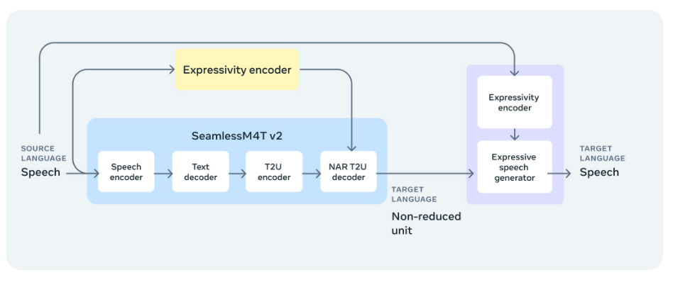

藍色回答「翻成什麼」；黃色與紫色補上「用什麼節奏與風格說」。

圖片：使用者提供的原始第一張截圖，完整保留。出處：[Meta SeamlessExpressive 官方介紹](https://ai.meta.com/blog/seamless-communication/)。

## 雙路徑控制：語意與表現力在哪裡會合？

### 翻譯主幹｜語意內容

- Speech encoder 編碼來源語音。
- Text decoder 產生**目標語言文字**。
- T2U 把文字表徵轉成語音單元。

### 表現力路徑｜節奏與風格

- 從**來源語音**取得表現力訊號。
- 引導 T2U 的節奏與 duration。
- 作為 expressive generator 的合成條件。

兩條路徑共同決定輸出；圖中箭頭表示條件傳遞，並非雙向回饋迴圈。

來源：使用者 RTF §2 與架構截圖；[Meta 官方介紹](https://ai.meta.com/blog/seamless-communication/)。

## SeamlessM4T v2：論文原始架構圖

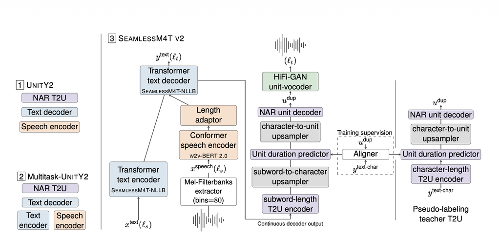

圖片：使用者提供的第二張原圖截圖，完整保留。[Seamless 論文 Figure 3／§3.3](https://arxiv.org/pdf/2312.05187#page=18)。

## UnitY2 基礎骨幹：簡化閱讀指引

[figure not shown]

先產生目標文字，再決定是否走第二階段的語音單元生成。

依使用者 RTF §3–4 重繪；[論文 §3.3、Figure 3](https://arxiv.org/pdf/2312.05187#page=18) 對照多任務結構。圖中省略訓練 loss 與部分內部模組。

## 前端：從聲學訊號到文字解碼的表徵

1. **80-bin Mel-filterbanks**：把音訊轉成隨時間變動的聲學特徵。
2. **w2v-BERT 2.0／Conformer**：建立深層語音表示。
3. **Length adaptor**：調整時間解析度，銜接後續解碼器。
4. **NLLB-based text decoder**：產生目標語言文字序列。

Length adaptor 處理前端表徵長度；T2U duration predictor 處理生成端的 unit 長度。

來源：使用者 RTF §3；[Meta 官方模型庫：w2v-BERT 2.0](https://github.com/facebookresearch/seamless_communication)。

## T2U：文字怎麼變成語音單元？

[figure not shown]

兩次長度轉換：**subword → character → unit**；duration 決定第二次展開。

來源：使用者 RTF §4；[論文 §3.3、Figure 3](https://arxiv.org/pdf/2312.05187#page=18)。此圖簡化支線與訓練標籤細節。

## Duration：預測每個字元要佔多久

[figure not shown]

展開後的總長度 = 各字元 duration 的總和；字元標籤只代表位置來源。

教學示意，數值為自行設計，未使用模型實測輸出。A／B／C 不是實際 speech unit ID。

## 為什麼使用 NAR unit decoder？

### 自迴歸｜AR

- 依先前輸出逐步生成下一個 token。
- 序列越長，需要越多次序列生成步驟。

### 非自迴歸｜NAR

- 先決定展開長度。
- 多個 unit 位置可在同一解碼階段預測。
- 降低逐一生成 unit 的相依性。

M4T v2 的第二階段 T2U 採用 NAR；文字解碼仍有自己的生成流程。

來源：使用者 RTF §4；[Transformers：v1／v2 架構差異](https://huggingface.co/docs/transformers/model_doc/seamless_m4t_v2#difference-with-seamlessm4t-v1)。

## 訓練期與推論期：Teacher 在哪裡？

| 階段 | 主要角色 | Duration 從哪裡來？ |
| --- | --- | --- |
| **訓練期** | Teacher T2U、Aligner 提供監督訊號 | 以對齊得到的 duration 訓練 predictor |
| **推論期** | 已訓練的 T2U、duration predictor、NAR decoder | 模型預測 duration，據此展開表徵 |

Teacher／aligner 用於教會模型如何對齊；一般推論不再依賴這條監督支線。

來源：使用者 RTF §4 的 training supervision 說明；[論文 Figure 3、§3.3.2](https://arxiv.org/pdf/2312.05187#page=18)。

## 回到 Expressive：兩處條件化各控制什麼？

| 使用位置 | 功能 | 希望保留的特徵 |
| --- | --- | --- |
| **Prosody UnitY2／T2U** | 用來源表現力條件引導 unit 生成與時長 | 語速、停頓與片語節奏 |
| **Expressive generator／PRETSSEL** | 結合 units 與來源表現力條件生成語音 | 語調、聲音風格與表達方式 |

只翻譯文字不足以重建完整表達方式；時長與聲學生成也需要來源語音條件。

來源：使用者 RTF §2、§5 與圖片文字；[Meta 官方介紹](https://ai.meta.com/blog/seamless-communication/)。

## Units 與波形：最後一段生成的差異

| 比較項目 | SeamlessM4T v2 | SeamlessExpressive |
| --- | --- | --- |
| Unit 生成 | 基礎 NAR T2U | 加入表現力條件的 T2U |
| 高階合成模組 | HiFi-GAN unit-vocoder | Expressive speech generator／PRETSSEL |
| 明確的來源表現力條件 | 未加入 Expressive 的控制路徑 | 來源語音引導節奏與風格 |

Expressive 更換基礎模型的 **unit-to-speech 流程**；PRETSSEL 內部仍使用 HiFi-GAN 將 Mel 特徵轉成波形。

來源：使用者 RTF §5；內部合成細節核對自 [論文 §4.2.1](https://arxiv.org/pdf/2312.05187#page=32)。

## 架構總結與 Q&A

語意靠翻譯骨幹，  
時間靠 duration，表達方式靠來源語音條件。

- **M4T v2／UnitY2**：多模態輸入 → 目標文字 → units → 語音。
- **T2U**：階層式上採樣＋duration predictor＋NAR unit decoder。
- **Expressive**：把表現力條件帶入 unit 與聲學生成。
- **Seamless 整合版**：串流讀寫決策＋部分語音條件下的表現力合成。

Q&A：如果譯文正確，但語速與停頓不自然，應先檢查哪一段？

## 資料來源與閱讀指引

| 資料 | 本簡報的用途 |
| --- | --- |
| **SeamlessM4T_for_codex.rtf** | 五段大綱、模型元件與講稿素材；文字備份見 `sources/` |
| **截圖與官方架構圖** | Expressive、UnitY2 原始截圖；Seamless 整合圖採用 Meta 官方原檔 |
| **[Seamless 論文](https://arxiv.org/abs/2312.05187)** | §3.3：UnitY2；§4.2：Expressive；§6：Seamless 整合版 |
| **[Meta 官方模型庫](https://github.com/facebookresearch/seamless_communication)** | 模型家族、任務與開源組件 |
| **[Transformers 官方文件](https://huggingface.co/docs/transformers/model_doc/seamless_m4t_v2)** | v2 生成流程與 NAR T2U 架構 |

樣式來源：Liu/_quarto.yml、Liu/styles.css、Liu/report.qmd。外部資料核對日期：2026-10-15。